# Ch. 16 HW due 3.13.22

Brenda Onyango

3/7/2022

## Non-coding Homework

### 1: Vacations

```r
vacationdata <- data.frame(individual=c("Zac", "Zac", "Zac", "Skylar", "Skylar", "Skylar"),
                           year=c("2012", "2013", "2014"),
                           vacations=c(3, 7, 5, 2, 6, 10),
                           meanvacation=c(5, 5, 5, 6, 6, 6),
                           withinvacation=c(-2, 2, 0, -4, 0, 4))

#display table
vacationdata
```

```
##   individual year vacations meanvacation withinvacation
## 1        Zac 2012         3            5             -2
## 2        Zac 2013         7            5              2
## 3        Zac 2014         5            5              0
## 4     Skylar 2012         2            6             -4
## 5     Skylar 2013         6            6              0
## 6     Skylar 2014        10            6              4
```

1. The numbers that represent the varation between Zac and Skylar in their vacation taking are 5 and 6, respectively. The average number of vacations that Zac took between 2012 and 2014 was 5 and for Skylar was 6.
2. The within variation of Zac is shown in the 5th column. In 2012, Zac took two fewer vacations than average, in 2013 Zack took 2 more than average, and in 2014 Zac took the same number of vacations as average. The variation within Skylar’s vacation taking is -4, 0, and 4 relative to the average of 6 per year.

```r
zac <- c(3, 7, 5)
skylar <- c(2, 6, 10)

var(zac)
```

```
## [1] 4
```

```r
var(skylar)
```

```
## [1] 16
```

Fixed effects focus on within variation so “the treatment effect estimated will focus a lot more heavily on people with a lot of within variation.” Given this, our fixed effects estimate will likely give us an answer closer to 2.

### 2: DAG

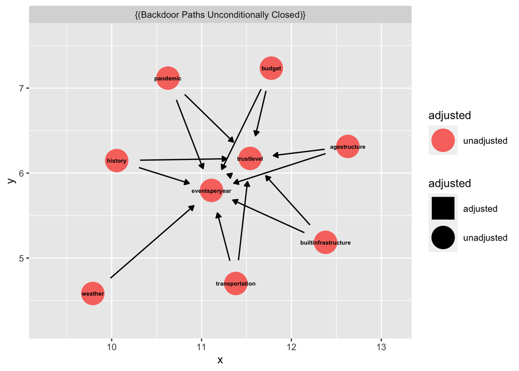

```r
citydag <- dagitty::dagitty("dag {

  trustlevel <- eventsperyear
  trustlevel <- builtinfrastructure -> eventsperyear
  trustlevel <- transportation -> eventsperyear
  trustlevel <- history -> eventsperyear
  trustlevel <- budget -> eventsperyear
  trustlevel <- agestructure -> eventsperyear
  trustlevel <- pandemic -> eventsperyear
  eventsperyear <- weather
  weather [exposure]
  trustlevel [outcome]
}") #eventsperyear is the true exposure

tidy_dag <- tidy_dagitty(citydag)

ggdag_adjustment_set(citydag, node_size = 10, text_size = 2.0, text_col = 'black')
```

The above dag shows that there are back doors between eventsperyear and citytrustlevels through built infrastructure (e.g., event space, parks, stadiums, etc.), transportation (e.g., public transportation and the quality of that transportation), budget, history, agestructure, and pandemic. Built infrastructure, transportation, budget, and history affect the ability of a city to host events and the willingness and ability of residents to attend events. Assuming these stay constant within a city, then the back doors of these variables can be closed with fixed effects. Agestructure (proportion of total population in age groups) is known to vary over time based on a lot of variables and age groups may vary in trust between each other. Pandemics are also not constant over time. Based on these assumptions builtinfrastructure, transportation, budget, and history can be combined in a DAG for fixed effects for city.

The new DAG would look like the below with agestructure and pandemic still open:

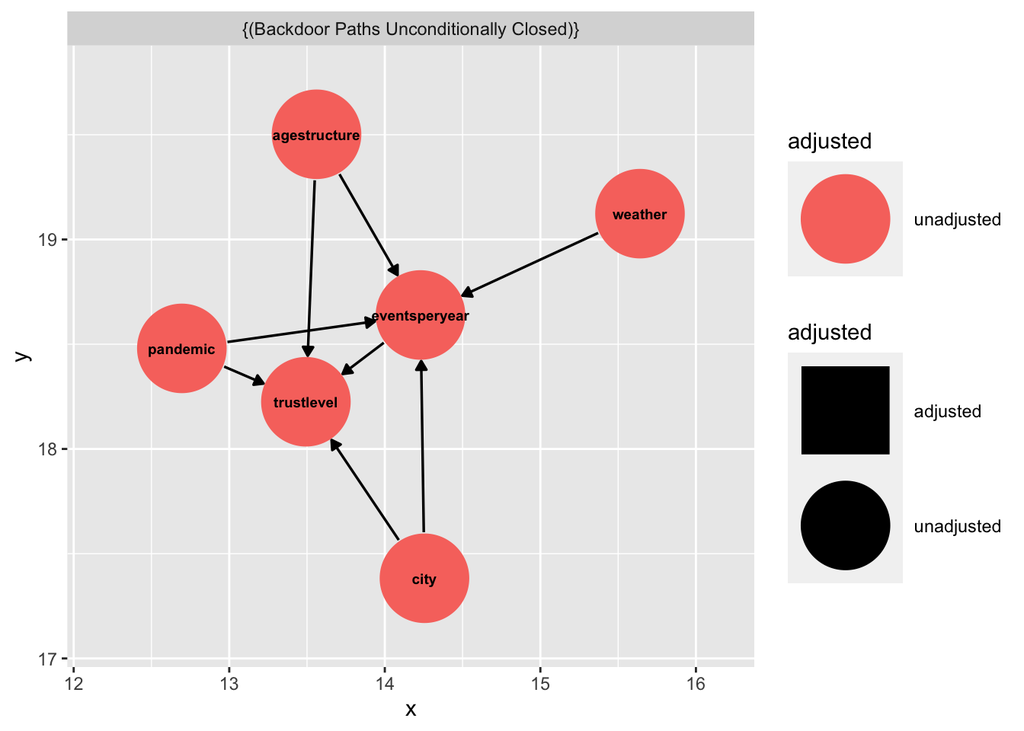

```r
citydag2 <- dagitty::dagitty("dag {

  trustlevel <- eventsperyear
  trustlevel <- city -> eventsperyear
    trustlevel <- pandemic -> eventsperyear
      trustlevel <- agestructure -> eventsperyear
  eventsperyear <- weather
  city [exposure]
  trustlevel [outcome]
}")

tidy_dag <- tidy_dagitty(citydag2)

ggdag_adjustment_set(citydag2, node_size = 20, text_size = 2.5, text_col = 'black')
```